# Biased transmission and transformation in birdsong

Mason Youngblood

6/14/2022

Please make sure that you have `sensitivity`, `truncnorm`, `data.table`, and (optionally) `abcrf` installed in RStudio.

```r
#install required packages
install.packages("evd")
install.packages("sensitivity")
install.packages("truncnorm")
install.packages("data.table")
install.packages("abcrf")
```

In this workshop we will build an agent-based model of biased transmission and transformation in swamp sparrow song (*Melospiza georgiana*). Swamp sparrow song is an excellent model of biased transmission and transformation because there is empirical evidence for the following:

1. Transformation: birds increase the trill rates of low-quality songs at the expense of learning accuracy [(Lahti et al., 2011)](https://onlinelibrary.wiley.com/doi/10.1111/j.1439-0310.2011.01930.x).
2. Selective attrition: birds are less likely to learn songs that are relatively hard to produce, imposing (one of several) upper bounds on trill rate [(Podos et al., 2004)](https://www.sciencedirect.com/science/article/pii/S0003347204002477).
3. Biased transmission: cultural evolutionary patterns in wild populations are consistent with conformity [(Lachlan et al., 2018)](https://www.nature.com/articles/s41467-018-04728-1).

Specifically, we will model how all of these factors influence the recovery of trill rate after a population crash. [Hudson and Creanza (2022)](https://onlinelibrary.wiley.com/doi/full/10.1111/evo.14489) recently found that birdsong characteristics may be simplified after a population crash, so we will model improvement in trill rate over time from a simpler starting point. Let’s get started!

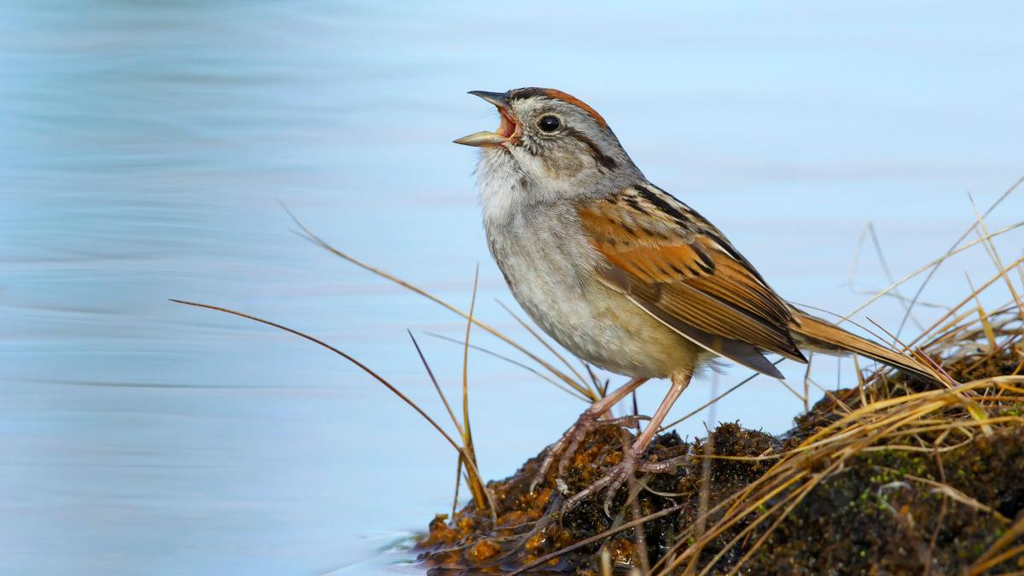

### Modeling transformation

First let’s take a look at how [Hudson and Creanza (2022)](https://onlinelibrary.wiley.com/doi/full/10.1111/evo.14489) modeled cultural transformation in birdsong using a modified version of the Price equation first introduced by [Henrich (2004)](https://www.jstor.org/stable/4128416?seq=1). `z_max` is the current maximum value of a trait in the population—in this case the maximum trill rate of a song type. To get the distribution of possible values for `z` in the next generation, we would generate a Gumbel distribution centered around `z_max - alpha` with variance controlled by `beta`. Let’s try this with `z_max` of 1, `alpha` of 0.4, and `beta` of 0.1, and we’ll truncate the distribution at 0 to prevent negative values.

```r
#set parameters
z_max <- 1
alpha <- 0.4
beta <- 0.1

#generate sequence and get distribution across it
sequence <- seq(0, 1.4, 0.01)
distribution <- sensitivity::dgumbel.trunc(sequence, loc = z_max-alpha, scale = beta, min = 0.0001)
```

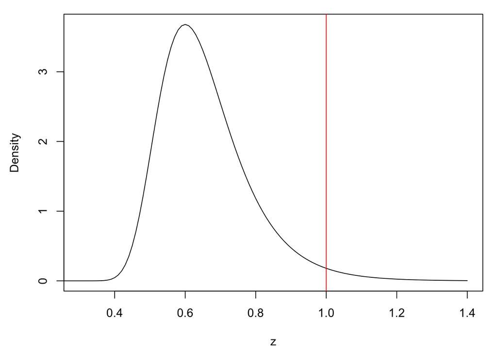

The red vertical line is the current `z_max` of the population, and the black distribution shows the possible values of `z` in the next generation. When `N` birds learn this particular song type, we will sample `N` values from this distribution and overwrite the current `z_max` with the largest value. In small populations this means that the trill rate will often decrease, whereas in large populations it will increase. This model assumes that new birds in the population can learn from anybody and use the best possible version of a song type as their target.

Let’s wrap this model in a basic function and iterate it out for 100 timesteps with different values of `N` to see what happens.

```r
#wrap model in function
sample_z <- function(N, z_max, alpha, beta){
  return(sensitivity::rgumbel.trunc(N, loc = z_max-alpha, scale = beta, min = 0.0001))
}

#simulate a changing song type in a small population of 20
small_pop <- c()
temp_z_max <- 1
for(i in 1:100){
  temp <- sample_z(20, temp_z_max, alpha, beta)
  small_pop <- c(small_pop, median(temp))
  temp_z_max <- max(temp)
}

#simulate a changing song type in a large population of 50
large_pop <- c()
temp_z_max <- 1
for(i in 1:100){
  temp <- sample_z(50, temp_z_max, alpha, beta)
  large_pop <- c(large_pop, median(temp))
  temp_z_max <- max(temp)
}
```

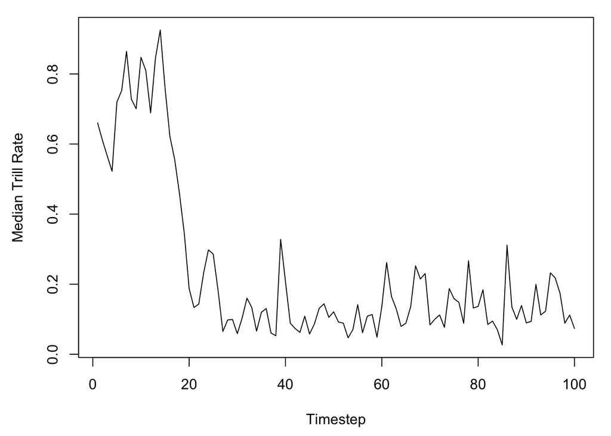

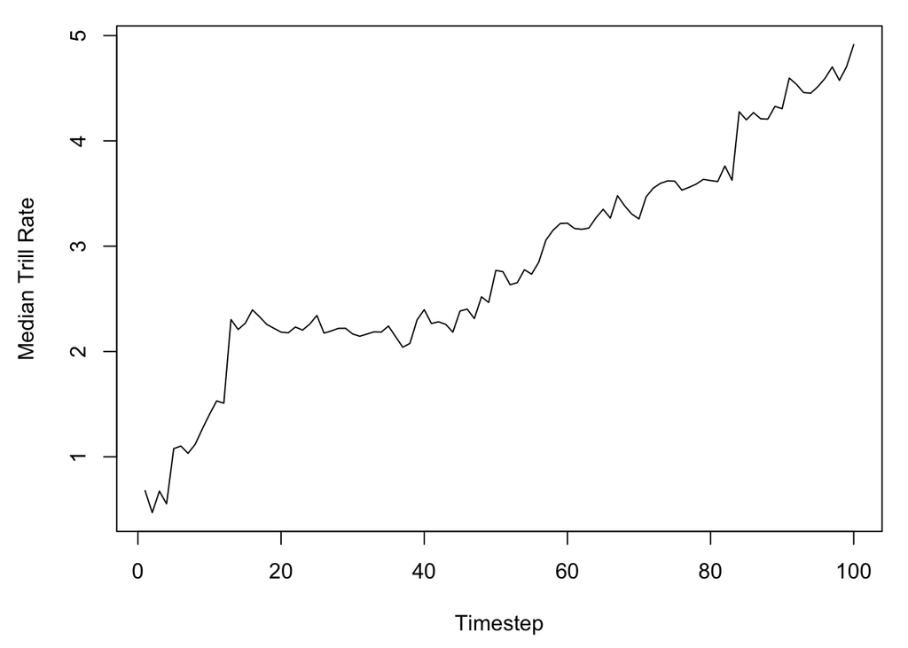

As expected the trill rate tends to increase when there are enough birds in each generation that at least one has a higher `z` than the previous `z_max`. Increasing `alpha` or reducing `beta` would slow down the rate of increase, but we’ll stick with the current values for now.

### Embedding in random copying model

Now let’s embed this transformation function into a random copying model. This model will simulate birds randomly copying songs from previous generations and slowly improving them over time. The first step is to store all possible songs that can exist in a data table, alongside the parameters for the transformation function with a bit of random jitter. Let’s assume that we have 160 `total_types`. The `price_params` object is a vector with the (1) mean `z_max`, (2) mean `alpha`, (3) mean `beta`, and (4) the standard deviation for all three (0.01). This way each song will start out with a slightly different trill rate and probability of improvement.

```r
#set parameters
total_types <- 160
price_params <- c(z_max, alpha, beta, 0.01)

#initialize songs in data table
songs <- data.table::data.table(type = 1:total_types,
                                z_max = truncnorm::rtruncnorm(total_types, a = 0, mean = price_params[1], sd = price_params[4]),
                                alpha = truncnorm::rtruncnorm(total_types, a = 0, mean = price_params[2], sd = price_params[4]),
                                beta = truncnorm::rtruncnorm(total_types, a = 0, mean = price_params[3], sd = price_params[4]))
```

```
##      type     z_max     alpha       beta
##   1:    1 0.9831994 0.4063408 0.10735331
##   2:    2 0.9937136 0.4009687 0.11539319
##   3:    3 1.0075132 0.3982207 0.10892382
##   4:    4 0.9771190 0.3974611 0.09374994
##   5:    5 1.0118267 0.3879200 0.09421731
##  ---
## 156:  156 1.0036539 0.4218236 0.09588026
## 157:  157 1.0075261 0.4050693 0.10438770
## 158:  158 0.9961763 0.4107374 0.11110388
## 159:  159 0.9864316 0.3895935 0.09563050
## 160:  160 0.9930980 0.3992367 0.08431388
```

As you can see, each song type has a numeric ID and slightly different parameters for the `sample_z` function. Now let’s create a data table where we will store our birds’ repertoires, or the songs that they have learned. Let’s assume that birds have a repertoire size of 10 songs, and that at the beginning of the model there are only 20 song types that exist in the population (before innovation happens). Let’s also set `N` to 200.

```r
#set parameters
N <- 200
init_types <- 20
rep_size <- 10

#initialize birds in data table
birds <- data.table::data.table(rep = lapply(1:N, function(x){sample(init_types, rep_size)}))
```

```
##                        rep
##   1:  2, 8, 1,11,15, 4,...
##   2: 17, 7, 3,13,11, 9,...
##   3:  1, 8,20,10,12,18,...
##   4: 18, 1,17,16,20,10,...
##   5:  1,11,20, 2,16, 6,...
##  ---
## 196:  5,14,18,11, 9,15,...
## 197: 15,17, 4,14,18,12,...
## 198: 11,14, 1,16,12,10,...
## 199:  4, 2,19, 7, 8,16,...
## 200: 18, 5,11, 4, 9,13,...
```

Each row corresponds to a bird, and `rep` contains a vector of song types for each bird.

Now let’s build up our loop that will simulate our generations of birds across the 100 `timesteps`.

```r
#set parameters
timesteps <- 100
b_d_rate <- 0.5
mu <- 0.2

#create output object
output <- list()

#for each timestep
for(i in 1:timesteps){
  #compile frequency table of songs in the population
  freq_table <- table(unlist(birds$rep))
  freq_table <- data.table::data.table(type = as.numeric(names(freq_table)), freq = as.numeric(freq_table), z_max = songs$z_max[as.numeric(names(freq_table))])

  #collect the median z values for each song in the population to output
  output[[i]] <- sapply(freq_table$type, function(x){median(sample_z(z_max = songs$z_max[x], alpha = songs$alpha[x], beta = songs$beta[x], N = N))})

  #new birds are born and learn song types proportional to their frequency in the population
  new_birds <- data.table::data.table(rep = lapply(1:(N*b_d_rate), function(x){sample(freq_table$type, rep_size, prob = freq_table$freq)}))

  #new birds sampled to innovate with probability mu replace song types with another from the total pool of songs with probability mu
  to_innovate <- which(sample(c(TRUE, FALSE), N*b_d_rate, prob = c(mu, 1-mu), replace = TRUE))
  for(j in to_innovate){
    new_rep <- new_birds$rep[[j]]
    num_innovate <- rbinom(1, rep_size, mu)
    new_rep[sample(rep_size, num_innovate)] <- sample(total_types, num_innovate)
    new_birds$rep[[j]] <- new_rep
  }

  #improvement of song types occurs among new birds
  to_improve <- sort(unique(unlist(new_birds$rep)))
  for(j in to_improve){
    new_z_max <- max(sample_z(z_max = songs$z_max[j], alpha = songs$alpha[j], beta = songs$beta[j], N = N*b_d_rate))
    songs$z_max[j] <- new_z_max
  }

  #add new birds to entire population and then simulate mortality
  birds <- data.table::rbindlist(list(birds, new_birds))
  birds <- birds[-sample(N+(N*b_d_rate), N*b_d_rate), ]
}
```

The output of this is a list, where each entry is the median `z` value for *each* of the songs that exist in that timestep. Since we want to run large number of these simulations and compare the output in bulk, let’s simplify this to just be the median `z` value across *all* of the songs and plot it.

```r
#simplify output to be median of medians
output <- sapply(1:length(output), function(x){median(output[[x]])})
```

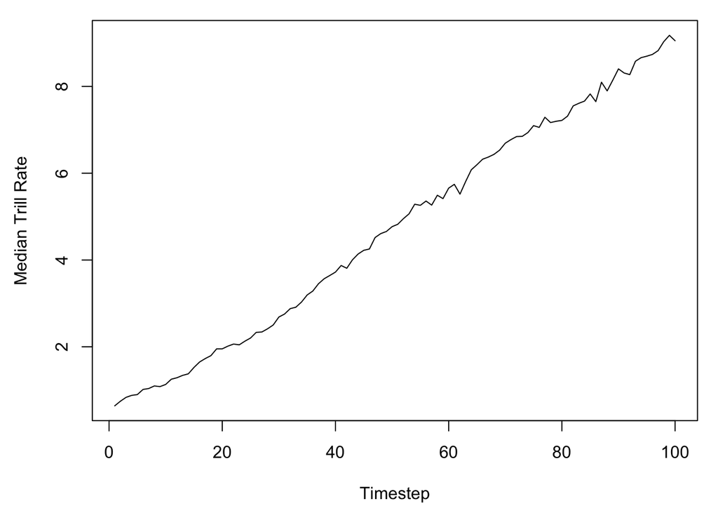

As you can see, with these parameter values we get a nice steady increase in the median trill rate of all songs in the population over time. This is not realistic—we need to add a downward constraint!

### Adding selective attrition

In songbirds, juveniles overlearn songs and then only produce a subset of them as adults through a process called selective attrition. In swamp sparrows, songs that are relatively difficult to produce are less likely to appear in crystallized repertoires [Podos et al. (2004)](https://www.sciencedirect.com/science/article/abs/pii/S0003347204002477). We can incorporate this into our model by making songs with higher `z_max` values less likely to be learned. To do this, we will modify the probability calculation in the `sample` function used when we generate our data table of new birds. Instead of `prob = freq_table$freq` it will be `prob = freq_table$freq*((1/freq_table$z_max)^attrition)`. When `attrition` is 0 then the second term will have no impact on the sampling probabilities and learning will be random. As `attrition` increases, songs with higher `z_max` values will be less and less likely to be learned, in effect “hitting the brakes” on improvement in a way that reflects learning constraints. Let’s set `attrition` to 1 and see what happens.

```r
#set parameter
attrition <- 1

#create output object
output <- list()

#for each timestep
for(i in 1:timesteps){
  #compile frequency table of songs in the population
  freq_table <- table(unlist(birds$rep))
  freq_table <- data.table::data.table(type = as.numeric(names(freq_table)), freq = as.numeric(freq_table), z_max = songs$z_max[as.numeric(names(freq_table))])

  #collect the median z values for each song in the population to output
  output[[i]] <- sapply(freq_table$type, function(x){median(sample_z(z_max = songs$z_max[x], alpha = songs$alpha[x], beta = songs$beta[x], N = N))})

  #new birds are born and learn song types proportional to their frequency in the population
  new_birds <- data.table::data.table(rep = lapply(1:(N*b_d_rate), function(x){sample(freq_table$type, rep_size, prob = freq_table$freq*((1/freq_table$z_max)^attrition))}))

  #new birds sampled to innovate with probability mu replace song types with another from the total pool of songs with probability mu
  to_innovate <- which(sample(c(TRUE, FALSE), N*b_d_rate, prob = c(mu, 1-mu), replace = TRUE))
  for(j in to_innovate){
    new_rep <- new_birds$rep[[j]]
    num_innovate <- rbinom(1, rep_size, mu)
    new_rep[sample(rep_size, num_innovate)] <- sample(total_types, num_innovate)
    new_birds$rep[[j]] <- new_rep
  }

  #improvement of song types occurs among new birds
  to_improve <- sort(unique(unlist(new_birds$rep)))
  for(j in to_improve){
    new_z_max <- max(sample_z(z_max = songs$z_max[j], alpha = songs$alpha[j], beta = songs$beta[j], N = N*b_d_rate))
    songs$z_max[j] <- new_z_max
  }

  #add new birds to entire population and then simulate mortality
  birds <- data.table::rbindlist(list(birds, new_birds))
  birds <- birds[-sample(N+(N*b_d_rate), N*b_d_rate), ]
}

#simplify output to be median of medians
output <- sapply(1:length(output), function(x){median(output[[x]])})
```

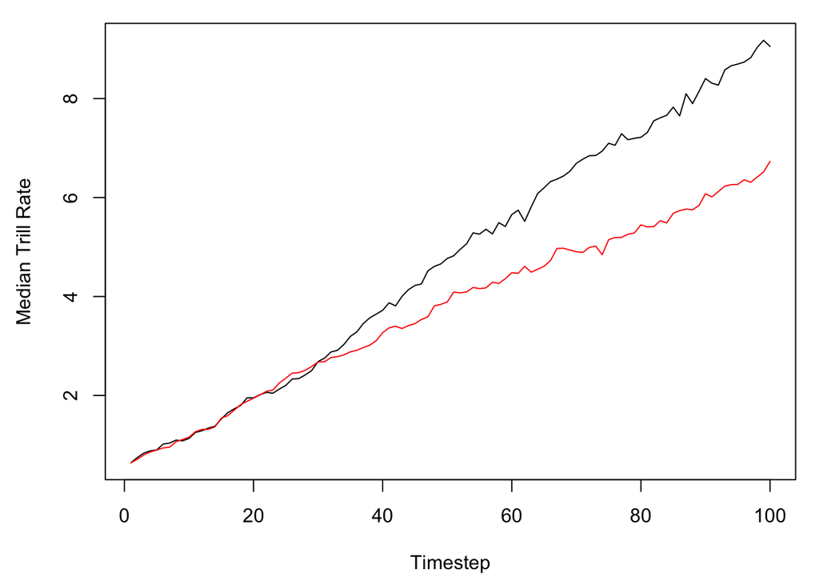

The red line above is the output of this new simulation that incorporates selective attrition biased by `z_max`.

### Adding conformity

One last element we will add to our model is conformity, or the tendency to favor songs that are already very common in the population [Lachlan et al. 2018](https://www.nature.com/articles/s41467-018-04728-1). Adding this is quite simple. All we do is exponentiate the song frequencies in the probability calculation when we generate our data table of new birds. Instead of `prob = freq_table$freq*((1/freq_table$z_max)^attrition)` (the version that already includes attrition) it will be `prob = (freq_table$freq^conformity)*((1/freq_table$z_max)^attrition)`. When `conformity` is 1 then nothing changes, but as it increase the more common songs will be more likely to be learned in each timestep. Let’s set `conformity` to 2 and see what happens.

```r
#set parameter
attrition <- 1
conformity <- 2

#create output object
output <- list()

#for each timestep
for(i in 1:timesteps){
  #compile frequency table of songs in the population
  freq_table <- table(unlist(birds$rep))
  freq_table <- data.table::data.table(type = as.numeric(names(freq_table)), freq = as.numeric(freq_table), z_max = songs$z_max[as.numeric(names(freq_table))])

  #collect the median z values for each song in the population to output
  output[[i]] <- sapply(freq_table$type, function(x){median(sample_z(z_max = songs$z_max[x], alpha = songs$alpha[x], beta = songs$beta[x], N = N))})

  #new birds are born and learn song types proportional to their frequency in the population
  new_birds <- data.table::data.table(rep = lapply(1:(N*b_d_rate), function(x){sample(freq_table$type, rep_size, prob = (freq_table$freq^conformity)*((1/freq_table$z_max)^attrition))}))

  #new birds sampled to innovate with probability mu replace song types with another from the total pool of songs with probability mu
  to_innovate <- which(sample(c(TRUE, FALSE), N*b_d_rate, prob = c(mu, 1-mu), replace = TRUE))
  for(j in to_innovate){
    new_rep <- new_birds$rep[[j]]
    num_innovate <- rbinom(1, rep_size, mu)
    new_rep[sample(rep_size, num_innovate)] <- sample(total_types, num_innovate)
    new_birds$rep[[j]] <- new_rep
  }

  #improvement of song types occurs among new birds
  to_improve <- sort(unique(unlist(new_birds$rep)))
  for(j in to_improve){
    new_z_max <- max(sample_z(z_max = songs$z_max[j], alpha = songs$alpha[j], beta = songs$beta[j], N = N*b_d_rate))
    songs$z_max[j] <- new_z_max
  }

  #add new birds to entire population and then simulate mortality
  birds <- data.table::rbindlist(list(birds, new_birds))
  birds <- birds[-sample(N+(N*b_d_rate), N*b_d_rate), ]
}

#simplify output to be median of medians
output <- sapply(1:length(output), function(x){median(output[[x]])})
```

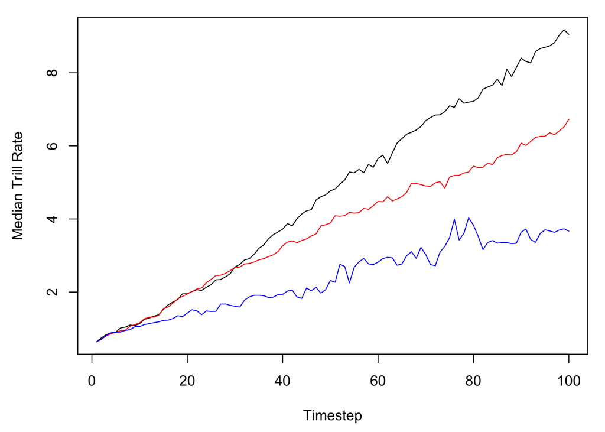

### Running in bulk

Realistically, we would like to run many iterations of this model to compare the output of it under different conditions. Let’s package it up as a function so we can do that.

```r
#create model function with default parameter values
model <- function(N = 200, b_d_rate = 0.5, timesteps = 100,
                  total_types = 160, init_types = 20, rep_size = 10,
                  mu = 0.2, attrition = 0, conformity = 1, price_params = c(1, 0.4, 0.1, 0.01)){
  #initialize songs in data table
  songs <- data.table::data.table(type = 1:total_types,
                                z_max = truncnorm::rtruncnorm(total_types, a = 0, mean = price_params[1], sd = price_params[4]),
                                alpha = truncnorm::rtruncnorm(total_types, a = 0, mean = price_params[2], sd = price_params[4]),
                                beta = truncnorm::rtruncnorm(total_types, a = 0, mean = price_params[3], sd = price_params[4]))

  #initialize birds in data table
  birds <- data.table::data.table(rep = lapply(1:N, function(x){sample(init_types, rep_size)}))

  #create output object
  output <- list()

  #for each timestep
  for(i in 1:timesteps){
    #compile frequency table of songs in the population
    freq_table <- table(unlist(birds$rep))
    freq_table <- data.table::data.table(type = as.numeric(names(freq_table)), freq = as.numeric(freq_table), z_max = songs$z_max[as.numeric(names(freq_table))])

    #collect the median z values for each song in the population to output
    output[[i]] <- sapply(freq_table$type, function(x){median(sample_z(z_max = songs$z_max[x], alpha = songs$alpha[x], beta = songs$beta[x], N = N))})

    #new birds are born and learn song types proportional to their frequency in the population
    new_birds <- data.table::data.table(rep = lapply(1:(N*b_d_rate), function(x){sample(freq_table$type, rep_size, prob = (freq_table$freq^conformity)*((1/freq_table$z_max)^attrition))}))

    #new birds sampled to innovate with probability mu replace song types with another from the total pool of songs with probability mu
    to_innovate <- which(sample(c(TRUE, FALSE), N*b_d_rate, prob = c(mu, 1-mu), replace = TRUE))
    for(j in to_innovate){
      new_rep <- new_birds$rep[[j]]
      num_innovate <- rbinom(1, rep_size, mu)
      new_rep[sample(rep_size, num_innovate)] <- sample(total_types, num_innovate)
      new_birds$rep[[j]] <- new_rep
    }

    #improvement of song types occurs among new birds
    to_improve <- sort(unique(unlist(new_birds$rep)))
    for(j in to_improve){
      new_z_max <- max(sample_z(z_max = songs$z_max[j], alpha = songs$alpha[j], beta = songs$beta[j], N = N*b_d_rate))
      songs$z_max[j] <- new_z_max
    }

    #add new birds to entire population and then simulate mortality
    birds <- data.table::rbindlist(list(birds, new_birds))
    birds <- birds[-sample(N+(N*b_d_rate), N*b_d_rate), ]
  }

  #output result
  return(sapply(1:length(output), function(x){mean(output[[x]])}))
}
```

Now we can set how many iterations we want and run them in serial or in parallel across multiple cores (commented examples below). Let’s run three rounds of 100 iterations of the model: (1) with the default parameters, (2) with `attrition` set to 1, and (3) with `conformity` set to 2.

```r
#set iterations
iters <- 100

#example in parallel
#output <- do.call(rbind, parallel::mclapply(1:iters, function(x){model()}, mc.cores = 8))

#example in serial
#output <- do.call(rbind, lapply(1:iters, function(x){model()}))

#run three rounds of the model
output_a <- do.call(rbind, parallel::mclapply(1:iters, function(x){model()}, mc.cores = 8))
output_b <- do.call(rbind, parallel::mclapply(1:iters, function(x){model(attrition = 1)}, mc.cores = 8))
output_c <- do.call(rbind, parallel::mclapply(1:iters, function(x){model(attrition = 1, conformity = 2)}, mc.cores = 8))
```

Plotting these is kind of complicated so here is the code. `matplot` is a great function that allows you to quickly plot a bunch of lines in a matrix. We provide `matplot` with a combined and transposed matrix of all of our model outputs. If we want we can also add the average value for each round of models at each timepoint.

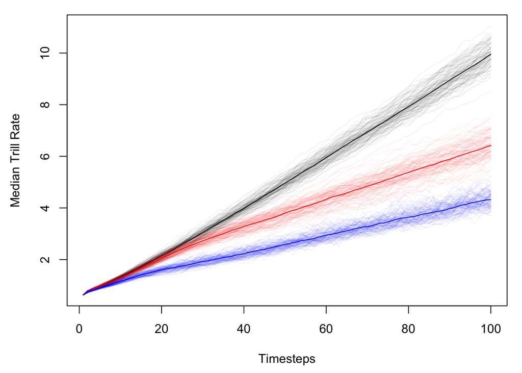

```r
#set opacity of the line colors
opacity <- 0.05

#generate vector of colors, one for each model result
colors <- c(rep(scales::alpha("black", opacity), nrow(output_a)),
            rep(scales::alpha("red", opacity), nrow(output_b)),
            rep(scales::alpha("blue", opacity), nrow(output_c)))

#adjust margins
par(mar = c(4.5, 4.5, 1, 1))

#plot lines
matplot(t(rbind(output_a, output_b, output_c)), type = "l", col = colors, lty = 1, xlab = "Timesteps", ylab = "Median Trill Rate")

#add average value lines
lines(colMeans(output_a), col = "black")
lines(colMeans(output_b), col = "red")
lines(colMeans(output_c), col = "blue")
```

### Questions (and solutions)

We have evidence that swamp sparrows have conformity bias in cultural transmission [(Lachlan et al., 2018)](https://www.nature.com/articles/s41467-018-04728-1). It must be adaptive in some way, and yet in our simulations above it appears to slow improvement over time. Please explore the following two questions (solutions provided).

#### 1. Under what conditions (if any) does conformity increase the rate of improvement over time?

Our innovation rate of 0.2 is very high. A lower value like 0.05 is much more realistic, and would allow songs to persist and improve in the population for a longer period of time. In this kind of situation, conformity may actually boost improvement over time by selecting for these persistent songs.

```r
#set iterations
iters <- 100

#run the two versions of the model with lower innovation rate
output_a <- do.call(rbind, parallel::mclapply(1:iters, function(x){model(attrition = 1, mu = 0.05)}, mc.cores = 8))
output_b <- do.call(rbind, parallel::mclapply(1:iters, function(x){model(attrition = 1, conformity = 2, mu = 0.05)}, mc.cores = 8))
```

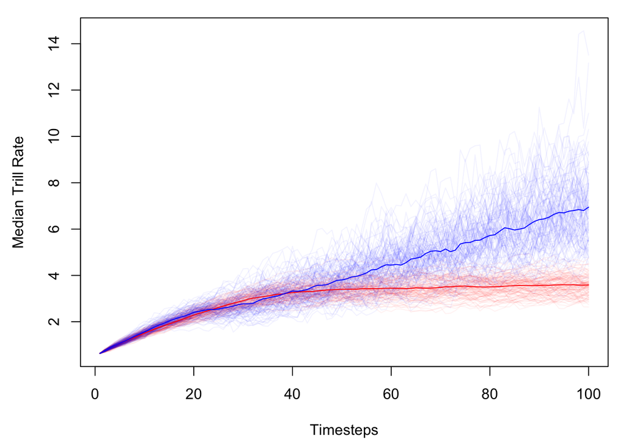

As you can see, lowering the innovation rate to a more reasonable value causes conformity to eventually boost the trill rate of the population.

#### 2. How do you think population size would affect the results of this model?

If we reduce our population size, then the trill rate will tend to go down over time from our starting point. The effect of conformity may vary in this situation as well.

```r
#set iterations
iters <- 100

#run the two versions of the model with lower population size
output_a <- do.call(rbind, parallel::mclapply(1:iters, function(x){model(N = 50, attrition = 1)}, mc.cores = 8))
output_b <- do.call(rbind, parallel::mclapply(1:iters, function(x){model(N = 50, attrition = 1, conformity = 2)}, mc.cores = 8))
```

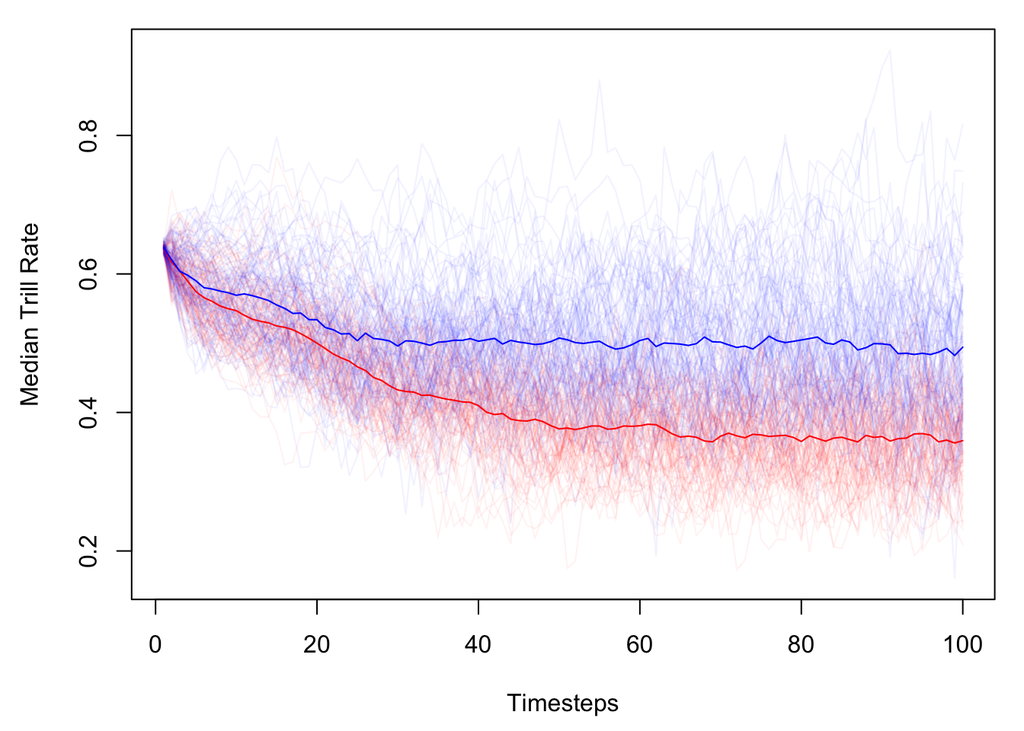

As you can see, when population size is lower and trill rate is decreasing over time, conformity actually slows that decrease.

### Bonus: generative inference!

One of the most useful applications of agent-based models like this one is [generative inference](https://royalsocietypublishing.org/doi/full/10.1098/rstb.2017.0056)—fitting it to real data to infer the processes that generated them. The most commonly used method for generative inference is approximate Bayesian computation, which is best conducted using [random forests](https://academic.oup.com/bioinformatics/article/35/10/1720/5132692) when your data are complex and require many summary statistics.

As an example, we’ll create some dummy data and pretend that it comes from a lab population of swamp sparrows with a known population size, turnover, etc. and try to use it to infer the level of conformity that is present. First let’s create this dummy data with `conformity` of 2 and the same parameter values used above. The output of our model is the average trill rate of the population in each timestep, and we’ll use each of these average trill rates as our summary statistics.

```r
#set random seed
set.seed(123)

#create dummy data for generative inference
obs_data <- model(attrition = 1, conformity = 2, mu = 0.05)
```

In order to conduct generative inference we need a large number of simulations across a range of possible values for out parameter of interest. In this case, let’s use a basic uniform distribution between 1 (neutrality) and 3 (strong conformity) and run 10,000 iterations. To run the simulations we’ll try out another package called `bettermc` that provides a status bar for parallelized code.

```r
#set iterations
iters <- 10000

#set prior
prior <- runif(iters, min = 1, max = 3)

#run and store the simulations
sum_stats <- do.call(rbind, bettermc::mclapply(1:iters, function(x){model(attrition = 1, conformity = prior[x], mu = 0.05)}, mc.cores = 8))

#combined and save
simulations <- list(prior = prior, sum_stats = sum_stats)
save(simulations, file = "simulations.RData")
```

Now we can conduct the inference process! First we build a regression random forest with the function `regAbcrf`. In real applications this requires a great deal of tuning, but for now let’s stick with the defaults.

```r
#combine summary statistics and prior into single object
inf_data <- cbind(data.frame(conformity = simulations$prior), data.frame(simulations$sum_stats))

#reshape observed data into data frame and rename to match simulated data
obs_data <- as.data.frame(t(obs_data))
colnames(obs_data) <- colnames(inf_data)[-1]

#create regression random forest
abc_rf <- abcrf::regAbcrf(formula = conformity ~ ., data = inf_data, ncores = 8, paral = TRUE)
```

And now that we have a trained random forest we can provide it with the observed data and ask it to predict the most likely value of conformity that is present in the population.

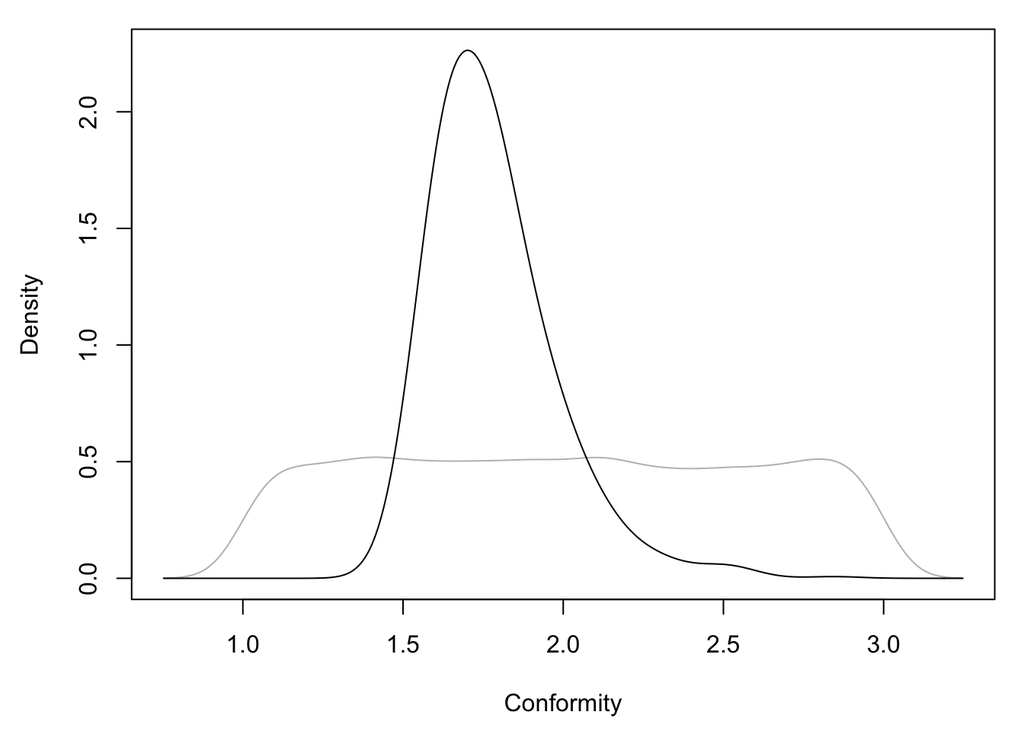

```r
#visualize posterior density
par(mar = c(4.5, 4.5, 1, 1))
abcrf::densityPlot(abc_rf, obs = obs_data, training = inf_data, main = NULL, xlab = "Conformity", ylab = "Density")
```

Email: masonyoungblood@gmail.com  
Twitter: [@MasYoungblood](https://twitter.com/MasYoungblood)